# Capstone 2

Yvonne Lam

11/11/2019

# Report

Objective: Make a prediction model to classify the arrival delay status of a flight

## Analysis

### Data Prep

Data is first cleaned by removing columns that are not useful and/or have many missing values. Especially for target variable, arr_delay, the whole row of data has to be removed as the target variable should not be manipulated. The two datasets are merged through time columns which have the same values. After which, columns with few missing values are imputed with median or mode values (which is selected after looking at the distribution of the variable and choosing a good majority value), to complete all entries in dataset.

```r
library(dplyr)
library(skimr)
library(lubridate)
#Data Prep
flight_records <- read.csv("case_data/data-flight.csv")
weather <- read.csv("case_data/data-weather.csv")
str(flight_records)
```

```
## 'data.frame':    4614 obs. of  17 variables:
##  $ year          : int  2013 2013 2013 2013 2013 2013 2013 2013 2013 2013 ...
##  $ month         : int  1 1 1 1 1 1 1 1 1 1 ...
##  $ day           : int  1 1 1 1 1 1 1 1 1 1 ...
##  $ dep_time      : int  629 643 811 1010 1211 1314 1457 1513 1725 1825 ...
##  $ sched_dep_time: int  630 645 815 1015 1215 1315 1500 1505 1730 1829 ...
##  $ dep_delay     : int  -1 -2 -4 -5 -4 -1 -3 8 -5 -4 ...
##  $ sched_arr_time: int  833 848 1016 1210 1413 1505 1656 1703 1926 2032 ...
##  $ arr_delay     : Factor w/ 2 levels "Delay","Not Delay": 2 2 1 2 1 2 2 1 2 1 ...
##  $ carrier       : Factor w/ 3 levels "EV","UA","US": 3 3 3 3 1 3 3 1 3 3 ...
##  $ flight        : int  1019 926 675 1103 4135 1615 720 4223 449 1973 ...
##  $ tailnum       : Factor w/ 412 levels "N10156","N102UW",..: 284 221 346 184 257 220 313 97 368 308 ...
##  $ origin        : Factor w/ 1 level "EWR": 1 1 1 1 1 1 1 1 1 1 ...
##  $ dest          : Factor w/ 1 level "CLT": 1 1 1 1 1 1 1 1 1 1 ...
##  $ distance      : int  529 529 529 529 529 529 529 529 529 529 ...
##  $ hour          : int  6 6 8 10 12 13 15 15 17 18 ...
##  $ minute        : int  30 45 15 15 15 15 0 5 30 29 ...
##  $ time_hour     : Factor w/ 3730 levels "2013-01-01 06:00:00",..: 1 1 2 3 4 5 6 6 7 8 ...
```

```r
skim(flight_records)
```

```
## Skim summary statistics
##  n obs: 4614
##  n variables: 17
##
## -- Variable type:factor --------------------------------------------------------
##   variable missing complete    n n_unique
##  arr_delay     120     4494 4614        2
##    carrier       0     4614 4614        3
##       dest       0     4614 4614        1
##     origin       0     4614 4614        1
##    tailnum      48     4566 4614      412
##  time_hour       0     4614 4614     3730
##                         top_counts ordered
##      Not: 2978, Del: 1516, NA: 120   FALSE
##   US: 2961, EV: 1651, UA: 2, NA: 0   FALSE
##                   CLT: 4614, NA: 0   FALSE
##                   EWR: 4614, NA: 0   FALSE
##  NA: 48, N19: 42, N56: 38, N56: 38   FALSE
##     201: 4, 201: 3, 201: 3, 201: 3   FALSE
##
## -- Variable type:integer -------------------------------------------------------
##        variable missing complete    n    mean      sd   p0  p25  p50  p75
##             day       0     4614 4614   15.72    8.77    1    8   16   23
##       dep_delay     111     4503 4614    9.57   37.77  -19   -6   -3    5
##        dep_time     111     4503 4614 1211.05  527.45    4  642 1229 1724
##        distance       0     4614 4614  529       0     529  529  529  529
##          flight       0     4614 4614 2437.39 1669.7   104  926 1895 4326
##            hour       0     4614 4614   11.91    5.09    5    6   12   17
##          minute       0     4614 4614   20.79   14.03    0   14   20   30
##           month       0     4614 4614    6.05    3.1     1    3    6    9
##  sched_arr_time       0     4614 4614 1401.75  511.11  640  846 1425 1923
##  sched_dep_time       0     4614 4614 1211.78  508.68  500  645 1230 1730
##            year       0     4614 4614 2013       0    2013 2013 2013 2013
##  p100     hist
##    31 ▇▇▇▇▆▇▇▆
##   486 ▇▁▁▁▁▁▁▁
##  2357 ▁▂▇▃▆▃▃▂
##   529 ▁▁▁▇▁▁▁▁
##  5909 ▇▇▇▁▁▆▅▂
##    21 ▇▃▂▃▃▂▃▂
##    59 ▆▂▇▅▅▁▂▁
##    11 ▇▅▃▇▅▃▃▇
##  2328 ▇▂▃▂▅▁▆▂
##  2130 ▇▂▃▃▃▁▆▂
##  2013 ▁▁▁▇▁▁▁▁
```

```r
#remove rows with missing arr_delay
flight_records <- flight_records[!is.na(flight_records$arr_delay),]

#remove columns that are not useful
colnames(flight_records)
```

```
##  [1] "year"           "month"          "day"            "dep_time"
##  [5] "sched_dep_time" "dep_delay"      "sched_arr_time" "arr_delay"
##  [9] "carrier"        "flight"         "tailnum"        "origin"
## [13] "dest"           "distance"       "hour"           "minute"
## [17] "time_hour"
```

```r
flight_records <- flight_records[, -c(1, 10, 12:14, 16)]

str(weather)
```

```
## 'data.frame':    7989 obs. of  14 variables:
##  $ year      : int  2013 2013 2013 2013 2013 2013 2013 2013 2013 2013 ...
##  $ month     : int  1 1 1 1 1 1 1 1 1 1 ...
##  $ day       : int  1 1 1 1 1 1 1 1 1 1 ...
##  $ hour      : int  1 2 3 4 5 6 7 8 9 10 ...
##  $ temp      : num  39 39 39 39.9 39 ...
##  $ dewp      : num  26.1 27 28 28 28 ...
##  $ humid     : num  59.4 61.6 64.4 62.2 64.4 ...
##  $ wind_dir  : int  270 250 240 250 260 240 240 250 260 260 ...
##  $ wind_speed: num  10.36 8.06 11.51 12.66 12.66 ...
##  $ wind_gust : num  NA NA NA NA NA NA NA NA NA NA ...
##  $ precip    : num  0 0 0 0 0 0 0 0 0 0 ...
##  $ pressure  : num  1012 1012 1012 1012 1012 ...
##  $ visib     : num  10 10 10 10 10 10 10 10 10 10 ...
##  $ time_hour : Factor w/ 7988 levels "2013-01-01 01:00:00",..: 1 2 3 4 5 6 7 8 9 10 ...
```

```r
skim(weather)
```

```
## Skim summary statistics
##  n obs: 7989
##  n variables: 14
##
## -- Variable type:factor --------------------------------------------------------
##   variable missing complete    n n_unique                     top_counts
##  time_hour       0     7989 7989     7988 201: 2, 201: 1, 201: 1, 201: 1
##  ordered
##    FALSE
##
## -- Variable type:integer -------------------------------------------------------
##  variable missing complete    n    mean     sd   p0  p25  p50  p75 p100
##       day       0     7989 7989   15.7    8.78    1    8   16   23   31
##      hour       0     7989 7989   11.49   6.92    0    5   11   17   23
##     month       0     7989 7989    6.01   3.15    1    3    6    9   11
##  wind_dir     247     7742 7989  195.25 109.49    0  110  220  280  360
##      year       0     7989 7989 2013      0    2013 2013 2013 2013 2013
##      hist
##  ▇▇▇▇▆▇▇▇
##  ▇▇▇▇▇▇▇▇
##  ▇▅▃▇▅▅▃▇
##  ▆▂▂▃▅▇▆▅
##  ▁▁▁▇▁▁▁▁
##
## -- Variable type:numeric -------------------------------------------------------
##    variable missing complete    n      mean     sd     p0     p25     p50
##        dewp       1     7988 7989   43.07   19.62   -9.04   27.95   44.6
##       humid       1     7988 7989   62.47   19.86   13.95   46.66   62.05
##      precip       0     7989 7989    0.0049  0.035   0       0       0
##    pressure     827     7162 7989 1017.66    7.42  983.9  1012.5  1017.4
##        temp       1     7988 7989   57.12   18.05   10.94   42.08   57.92
##       visib       0     7989 7989    9.35    1.9     0.12   10      10
##   wind_gust    6270     1719 7989   24.16    5.65   16.11   19.56   23.02
##  wind_speed       1     7988 7989    9.51   12.8     0       5.75    9.21
##      p75    p100     hist
##    60.08   75.92 ▁▂▅▇▆▇▇▆
##    78.65  100    ▁▃▇▇▇▇▆▅
##     0       1.21 ▇▁▁▁▁▁▁▁
##  1022.77 1041.9  ▁▁▁▅▇▆▂▁
##    71.96  100.04 ▁▃▆▆▇▇▅▁
##    10      10    ▁▁▁▁▁▁▁▇
##    27.62   58.69 ▇▇▃▂▁▁▁▁
##    12.66 1048.36 ▇▁▁▁▁▁▁▁
```

```r
#remove columns that are not useful(year, wind_gust, pressure)
colnames(weather)
```

```
##  [1] "year"       "month"      "day"        "hour"       "temp"
##  [6] "dewp"       "humid"      "wind_dir"   "wind_speed" "wind_gust"
## [11] "precip"     "pressure"   "visib"      "time_hour"
```

```r
weather <- weather[,-c(1, 10, 12)]

#check duplicated time_hour row
weather[duplicated(weather$time_hour),]
```

```
##      month day hour temp  dewp humid wind_dir wind_speed precip visib
## 7320    11   3    1   50 39.02  65.8      290     5.7539      0    10
##                time_hour
## 7320 2013-11-03 01:00:00
```

```r
weather[7315:7325,]
```

```
##      month day hour  temp  dewp humid wind_dir wind_speed precip visib
## 7315    11   2   16 64.94 42.98 44.78      290   13.80936      0    10
## 7316    11   2   17 62.96 44.06 50.03      290   11.50780      0    10
## 7317    11   2   18 60.98 41.00 47.70      290    9.20624      0    10
## 7318    11   2   19 60.08 39.92 47.22      300    9.20624      0    10
## 7319    11   3    1 51.98 39.02 61.15      310    6.90468      0    10
## 7320    11   3    1 50.00 39.02 65.80      290    5.75390      0    10
## 7321    11   3    2 51.08 39.92 65.48      330    8.05546      0    10
## 7322    11   3    3 51.08 41.00 68.28      320    8.05546      0    10
## 7323    11   3    4 50.00 42.08 74.10      340   11.50780      0    10
## 7324    11   3    5 48.92 39.92 70.95      350   12.65858      0    10
## 7325    11   3    6 48.02 37.04 65.56      340   17.26170      0    10
##                time_hour
## 7315 2013-11-02 16:00:00
## 7316 2013-11-02 17:00:00
## 7317 2013-11-02 18:00:00
## 7318 2013-11-02 19:00:00
## 7319 2013-11-03 01:00:00
## 7320 2013-11-03 01:00:00
## 7321 2013-11-03 02:00:00
## 7322 2013-11-03 03:00:00
## 7323 2013-11-03 04:00:00
## 7324 2013-11-03 05:00:00
## 7325 2013-11-03 06:00:00
```

```r
#the other data in row 7319 and 7320 are not identical yet they are close, time_hour could be a typo
weather[7319,3] <- 0

#join data frames
joined <- merge(flight_records,weather, by = c("month", "day", "hour", "time_hour"))

head(joined)
```

```
##   month day hour           time_hour dep_time sched_dep_time dep_delay
## 1     1   1   10 2013-01-01 10:00:00     1010           1015        -5
## 2     1   1   13 2013-01-01 13:00:00     1314           1315        -1
## 3     1   1   15 2013-01-01 15:00:00     1513           1505         8
## 4     1   1   15 2013-01-01 15:00:00     1457           1500        -3
## 5     1   1   17 2013-01-01 17:00:00     1725           1730        -5
## 6     1   1   18 2013-01-01 18:00:00     1825           1829        -4
##   sched_arr_time arr_delay carrier tailnum  temp  dewp humid wind_dir
## 1           1210 Not Delay      US  N162UW 41.00 28.04 59.65      260
## 2           1505 Not Delay      US  N177US 39.20 28.40 69.67      330
## 3           1703     Delay      EV  N13914 37.94 24.08 57.04      290
## 4           1656 Not Delay      US  N539UW 37.94 24.08 57.04      290
## 5           1926 Not Delay      US  N680AW 35.96 19.04 49.83      330
## 6           2032     Delay      US  N460UW 33.98 15.08 45.43      310
##   wind_speed precip visib
## 1   13.80936      0    10
## 2   16.11092      0    10
## 3    9.20624      0    10
## 4    9.20624      0    10
## 5   11.50780      0    10
## 6   12.65858      0    10
```

```r
#check missing values
colSums(is.na(joined))
```

```
##          month            day           hour      time_hour       dep_time
##              0              0              0              0              0
## sched_dep_time      dep_delay sched_arr_time      arr_delay        carrier
##              0              0              0              0              0
##        tailnum           temp           dewp          humid       wind_dir
##              0              1              1              1            171
##     wind_speed         precip          visib
##              1              0              0
```

```r
skim(joined)
```

```
## Skim summary statistics
##  n obs: 4482
##  n variables: 18
##
## -- Variable type:factor --------------------------------------------------------
##   variable missing complete    n n_unique
##  arr_delay       0     4482 4482        2
##    carrier       0     4482 4482        3
##    tailnum       0     4482 4482      412
##  time_hour       0     4482 4482     3632
##                          top_counts ordered
##         Not: 2972, Del: 1510, NA: 0   FALSE
##    US: 2905, EV: 1575, UA: 2, NA: 0   FALSE
##  N19: 42, N56: 38, N56: 38, N17: 37   FALSE
##      201: 4, 201: 3, 201: 3, 201: 3   FALSE
##
## -- Variable type:integer -------------------------------------------------------
##        variable missing complete    n    mean     sd  p0 p25  p50  p75
##             day       0     4482 4482   15.73   8.77   1   8   16   23
##       dep_delay       0     4482 4482    9.5   37.63 -19  -6   -3    5
##        dep_time       0     4482 4482 1210.5  526.57   4 642 1229 1724
##            hour       0     4482 4482   11.84   5.07   5   6   12   17
##           month       0     4482 4482    6.07   3.11   1   3    6    9
##  sched_arr_time       0     4482 4482 1394.87 509.84 640 846 1422 1919
##  sched_dep_time       0     4482 4482 1204.96 507.32 500 645 1229 1730
##        wind_dir     171     4311 4482  194.97 109.44   0 110  230  280
##  p100     hist
##    31 ▇▇▇▇▆▇▇▆
##   486 ▇▁▁▁▁▁▁▁
##  2357 ▁▂▇▃▆▃▃▂
##    21 ▇▃▂▃▃▂▃▂
##    11 ▇▅▃▇▅▃▃▇
##  2328 ▇▂▃▂▅▁▅▂
##  2130 ▇▂▃▃▃▁▆▂
##   360 ▆▂▂▃▃▇▆▅
##
## -- Variable type:numeric -------------------------------------------------------
##    variable missing complete    n    mean    sd    p0   p25   p50   p75
##        dewp       1     4481 4482 43.24   19.46 -7.96 28.04 44.96 60.08
##       humid       1     4481 4482 60.95   20.24 13.95 44.74 59.84 77.83
##      precip       0     4482 4482  0.0045  0.03  0     0     0     0
##        temp       1     4481 4482 58.13   18.04 10.94 42.98 59    73.04
##       visib       0     4482 4482  9.35    1.87  0.12 10    10    10
##  wind_speed       1     4481 4482  9.66    5.31  0     5.75  9.21 12.66
##    p100     hist
##   75.92 ▁▃▅▇▆▇▇▆
##  100    ▁▃▇▇▇▆▆▅
##    0.57 ▇▁▁▁▁▁▁▁
##  100.04 ▁▃▆▆▇▇▅▁
##   10    ▁▁▁▁▁▁▁▇
##   42.58 ▃▇▅▂▁▁▁▁
```

```r
#impute median value for temp, dewp, humid and wind_speed
colnames(joined)
```

```
##  [1] "month"          "day"            "hour"           "time_hour"
##  [5] "dep_time"       "sched_dep_time" "dep_delay"      "sched_arr_time"
##  [9] "arr_delay"      "carrier"        "tailnum"        "temp"
## [13] "dewp"           "humid"          "wind_dir"       "wind_speed"
## [17] "precip"         "visib"
```

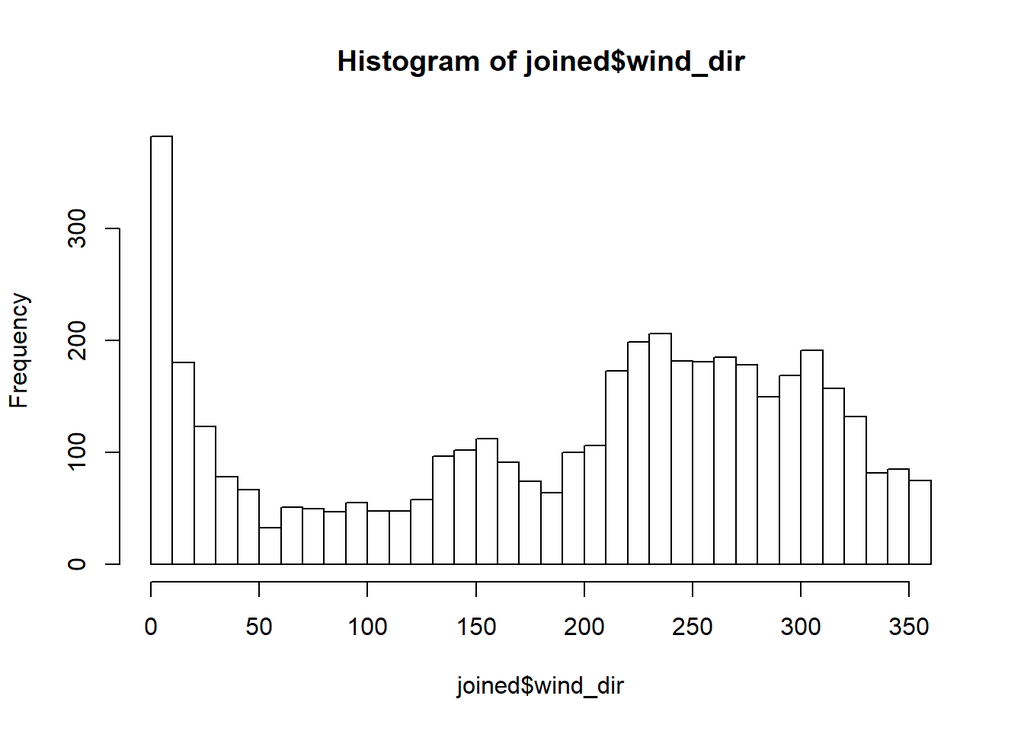

```r
joined[is.na(joined$temp), 12] <- median(joined$temp, na.rm=T)
joined[is.na(joined$dewp), 13] <- median(joined$dewp, na.rm=T)
joined[is.na(joined$humid), 14] <- median(joined$humid, na.rm=T)
joined[is.na(joined$wind_speed), 16] <- median(joined$wind_speed, na.rm=T)

#impute mode value for missing wind_dir, change 360 to 0 degrees as well
hist(joined$wind_dir, breaks = 30)
```

```r
joined[is.na(joined$wind_dir), 15] <- 0
joined[joined$wind_dir == 360, 15] <- 0

#check remaining missing values
colSums(is.na(joined))
```

```
##          month            day           hour      time_hour       dep_time
##              0              0              0              0              0
## sched_dep_time      dep_delay sched_arr_time      arr_delay        carrier
##              0              0              0              0              0
##        tailnum           temp           dewp          humid       wind_dir
##              0              0              0              0              0
##     wind_speed         precip          visib
##              0              0              0
```

**Feature Engineering**  
New columns are created to have features to aid the subsequent modelling ability.

```r
head(joined)
```

```
##   month day hour           time_hour dep_time sched_dep_time dep_delay
## 1     1   1   10 2013-01-01 10:00:00     1010           1015        -5
## 2     1   1   13 2013-01-01 13:00:00     1314           1315        -1
## 3     1   1   15 2013-01-01 15:00:00     1513           1505         8
## 4     1   1   15 2013-01-01 15:00:00     1457           1500        -3
## 5     1   1   17 2013-01-01 17:00:00     1725           1730        -5
## 6     1   1   18 2013-01-01 18:00:00     1825           1829        -4
##   sched_arr_time arr_delay carrier tailnum  temp  dewp humid wind_dir
## 1           1210 Not Delay      US  N162UW 41.00 28.04 59.65      260
## 2           1505 Not Delay      US  N177US 39.20 28.40 69.67      330
## 3           1703     Delay      EV  N13914 37.94 24.08 57.04      290
## 4           1656 Not Delay      US  N539UW 37.94 24.08 57.04      290
## 5           1926 Not Delay      US  N680AW 35.96 19.04 49.83      330
## 6           2032     Delay      US  N460UW 33.98 15.08 45.43      310
##   wind_speed precip visib
## 1   13.80936      0    10
## 2   16.11092      0    10
## 3    9.20624      0    10
## 4    9.20624      0    10
## 5   11.50780      0    10
## 6   12.65858      0    10
```

```r
#convert time_hour from factor to time-based
joined$time_hour <- ymd_hms(joined$time_hour)

#convert tailnum to character
joined$tailnum <- as.character(joined$tailnum)

#create dep_period, hours split into 3 time periods: Morning, Afternoon, Evening
joined <- joined %>%
  mutate(dep_period = case_when(hour <=10 ~ "Morning",
                                hour >10 & hour <=16 ~ "Afternoon",
                                hour >16 ~ "Evening"))
joined$dep_period <- as.factor(joined$dep_period)

#convert month and hour from integer to factor
joined$hour <- as.factor(joined$hour)
joined$month <- as.factor(joined$month)

#create days of week column
joined$weekdays <- as.factor(weekdays(joined$time_hour))

#create dep_delay_class column (dep_delay<=15 is 0(short), >15 is 1(long))
joined <- joined %>%
  mutate(dep_delay_class = case_when(dep_delay <= 15 ~ 1,
                                     dep_delay >  15 ~ 2))
```

### Exploratory Data Analysis

Data is explored based on time, elapsed air time and weather variables to see if there are more useful information which can be used to classify the flight delays further.

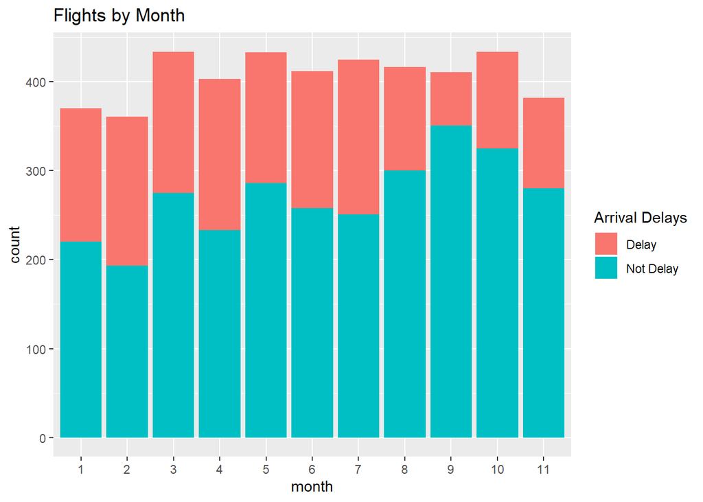

```r
library(ggplot2)
#by month, day, hour
joined %>%
  group_by(month) %>%
  ggplot(aes(x=month, fill=arr_delay))+
  geom_bar()+
  labs(title="Flights by Month", fill="Arrival Delays")
```

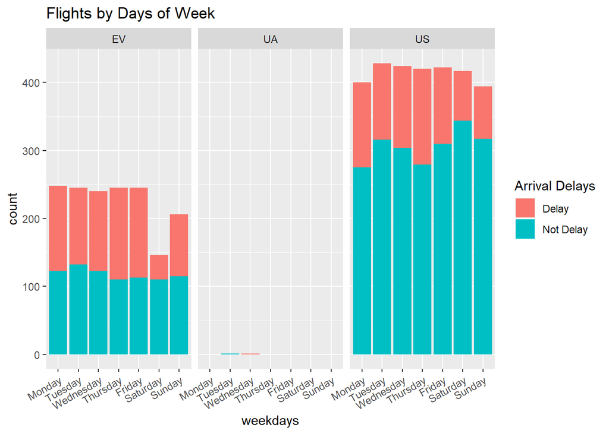

```r
joined$weekdays <- factor(joined$weekdays, levels = c("Monday", "Tuesday", "Wednesday", "Thursday", "Friday", "Saturday", "Sunday"))
ggplot(joined)+
  geom_bar(aes(x=weekdays, fill=arr_delay))+
  facet_wrap(~carrier)+
  labs(title="Flights by Days of Week", fill="Arrival Delays")+
  theme(axis.text.x = element_text(angle=30, hjust=1,vjust = 1))
```

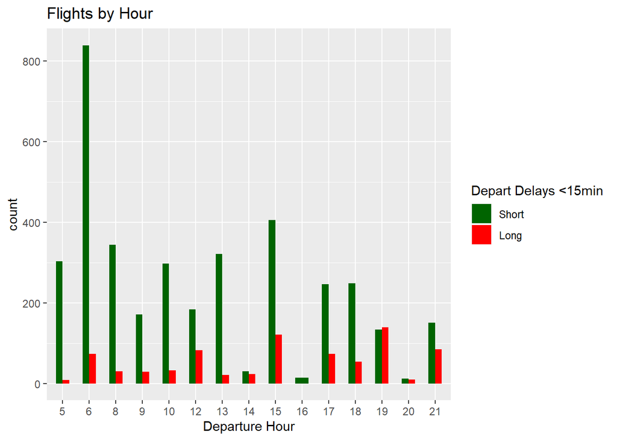

```r
# Airline carrier EV might need this prediction model more than the other two airline carriers, as they have a higher proportion of delays to no delays.

joined %>%
  group_by(hour) %>%
  ggplot(aes(x=as.factor(hour), fill=as.factor(dep_delay_class)))+
  geom_bar(position = "dodge", width = 0.5)+
  labs(title="Flights by Hour", x="Departure Hour", fill="Depart Delays <15min")+
  scale_fill_manual(values=c("darkgreen", "red"), labels = c("Short", "Long"))
```

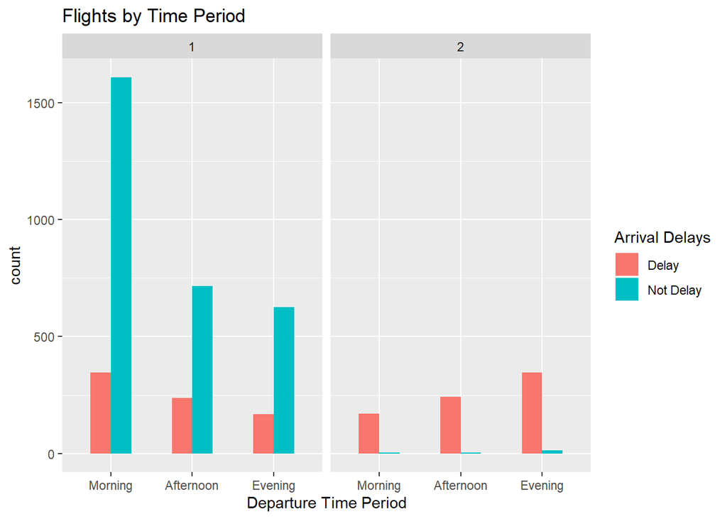

```r
#afternoon/night time flying has more delays compared to morning flights

joined$dep_period <- factor(joined$dep_period, levels=c("Morning", "Afternoon", "Evening"))
dep_delay_class_lab <- c("Short","Long")
joined %>%
  group_by(dep_period) %>%
  ggplot(aes(x=dep_period, fill=arr_delay))+
  geom_bar(position ="dodge",width = 0.5)+
  labs(title="Flights by Time Period", fill="Arrival Delays", x="Departure Time Period")+
  facet_wrap(~dep_delay_class)
```

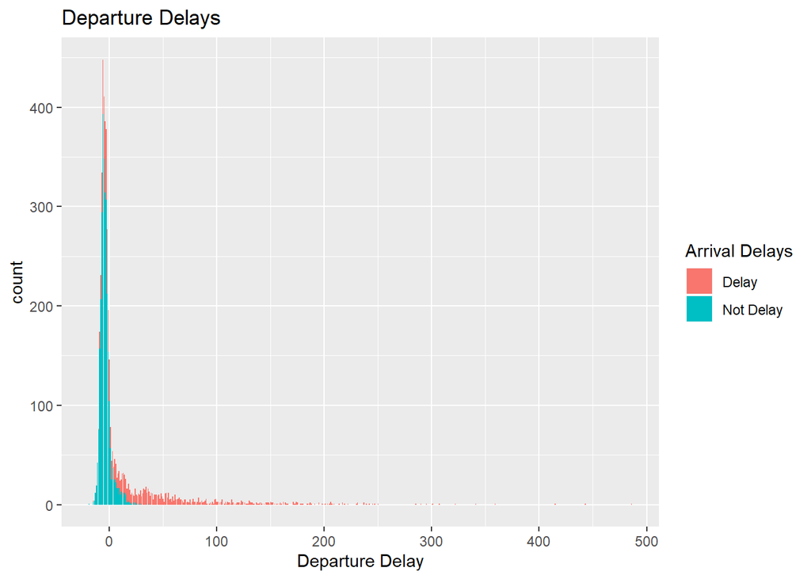

```r
#by pre-depart
joined %>%
  group_by(dep_delay) %>%
  ggplot(aes(x=dep_delay, fill=arr_delay))+
  geom_bar()+
  labs(title="Departure Delays", fill="Arrival Delays", x="Departure Delay")
```

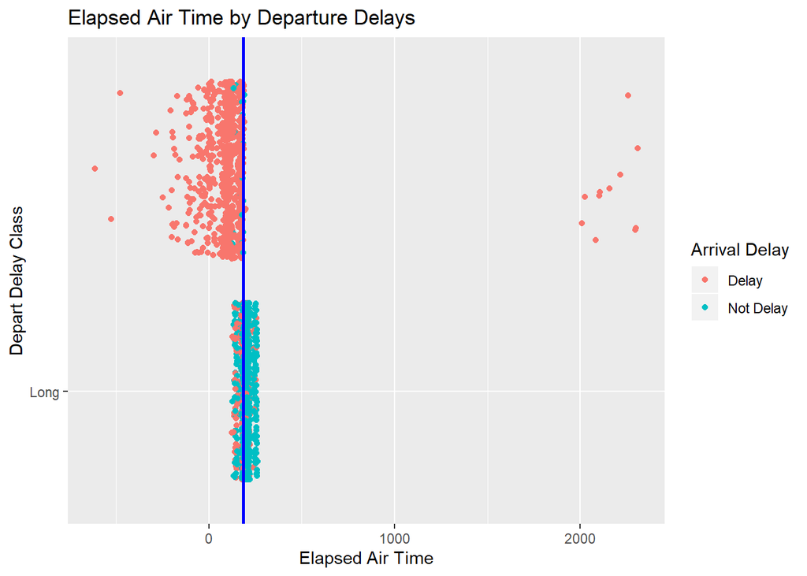

```r
#by elapsed air time
ggplot(joined, aes(x=(sched_arr_time-dep_time), y=as.factor(dep_delay_class), colour=arr_delay))+
  geom_jitter()+
  geom_vline(aes(xintercept= mean(sched_arr_time-dep_time)), col="blue", lwd=1)+
  labs(title="Elapsed Air Time by Departure Delays", colour ="Arrival Delay",
       x="Elapsed Air Time", y="Depart Delay Class")+
  scale_y_discrete(breaks = c(0,1), labels = c("Short", "Long"))
```

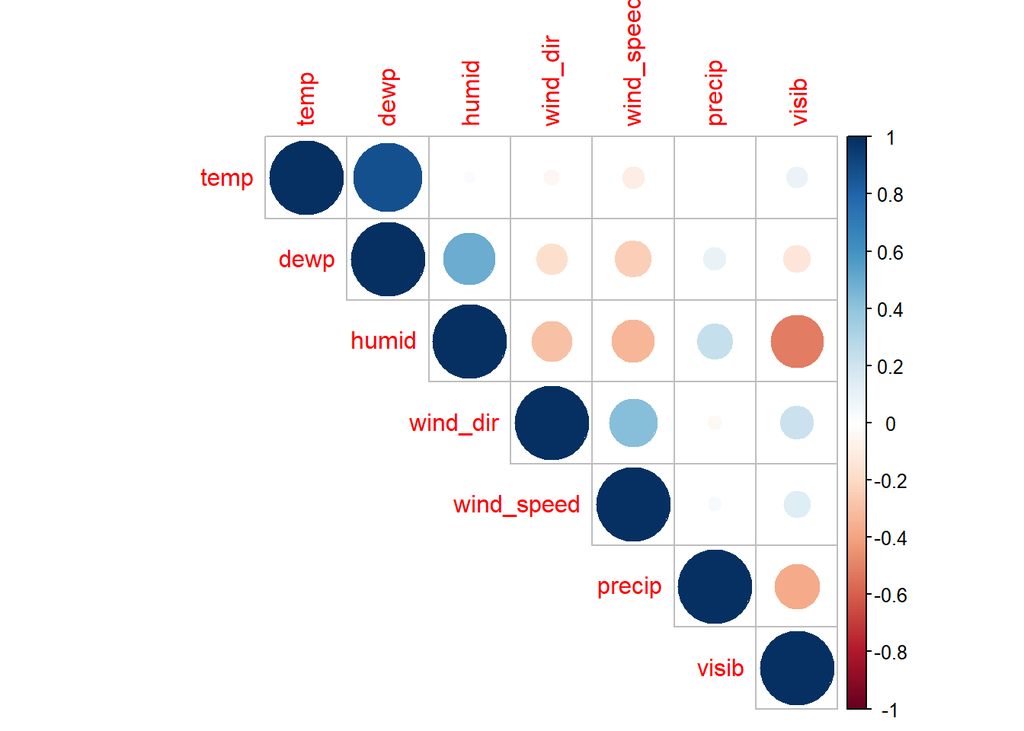

```r
#by weather variables

#correlations of weather variables
corrplot::corrplot(cor(joined[,12:18]), type="upper")
```

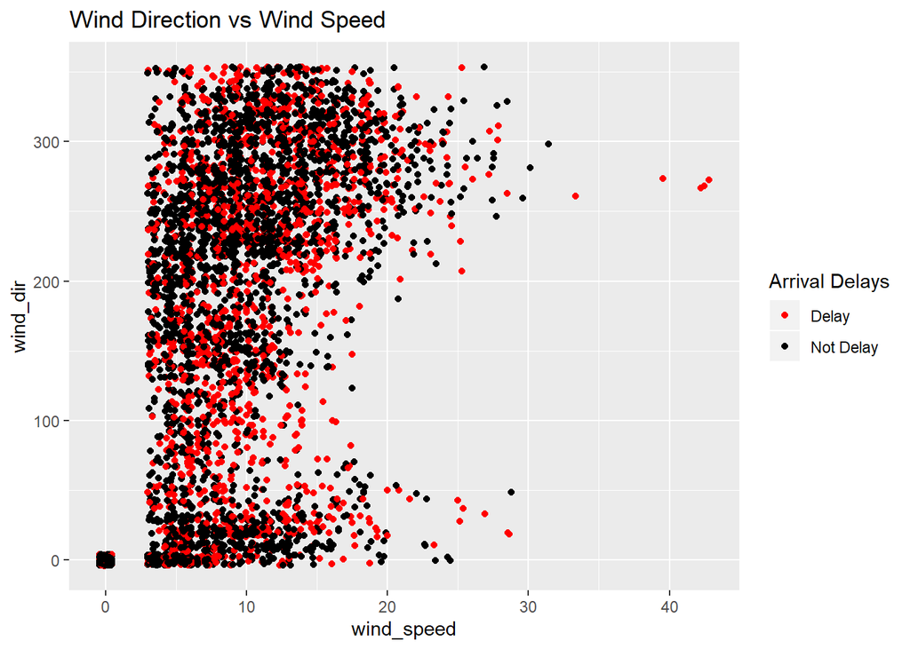

```r
# humid is closely related to many other weather variables, consider dropping it

ggplot(joined)+
  geom_jitter(aes(x=wind_speed, y= wind_dir, colour=arr_delay))+
  scale_color_manual(values=c("red", "black"))+
  labs(title="Wind Direction vs Wind Speed", colour="Arrival Delays")
```

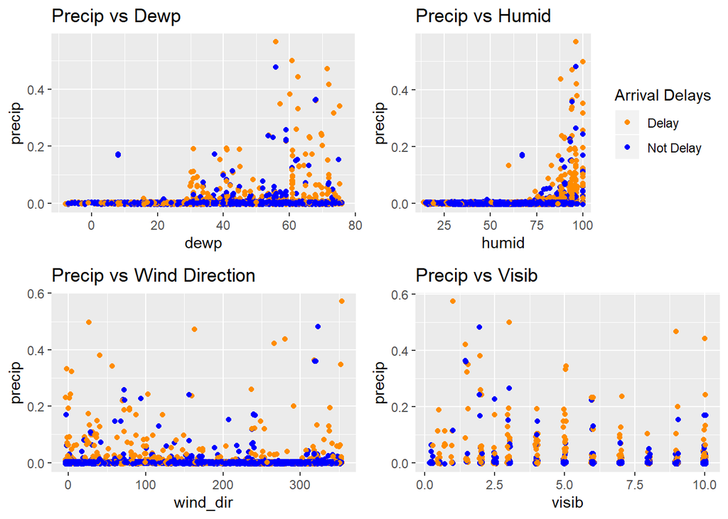

```r
g1 <- ggplot(joined)+
  geom_jitter(aes(x=dewp, y=precip, colour=arr_delay), show.legend = F)+
  scale_color_manual(values=c("darkorange", "blue"))+
  labs(title="Precip vs Dewp")
#high precip and dewp more likely to cause delay

g2 <- ggplot(joined)+
  geom_jitter(aes(x=humid, y=precip, colour=arr_delay))+
  scale_color_manual(values=c("darkorange", "blue"))+
  labs(title="Precip vs Humid", colour="Arrival Delays")

g3 <- ggplot(joined)+
  geom_jitter(aes(x=wind_dir, y=precip, colour=arr_delay), show.legend = F)+
  scale_color_manual(values=c("darkorange", "blue"))+
  labs(title="Precip vs Wind Direction")

g4 <- ggplot(joined)+
  geom_jitter(aes(x=visib, y=precip, colour=arr_delay), show.legend = F)+
  scale_color_manual(values=c("darkorange", "blue"))+
  labs(title="Precip vs Visib")

g5 <- ggplot(joined)+
  geom_jitter(aes(x=visib, y=dewp, colour=arr_delay), show.legend = F)+
  scale_color_manual(values=c("darkorange", "blue"))+
  labs(title="Dewp vs Visib")

g6 <- ggplot(joined)+
  geom_jitter(aes(x=visib, y=humid, colour=arr_delay), show.legend = F)+
  scale_color_manual(values = c("darkorange", "blue"))+
  labs(title = "Humid vs Visib")

g7 <- ggplot(joined)+
  geom_jitter(aes(x=visib, y=temp, colour=arr_delay))+
  scale_color_manual(values = c("darkorange", "blue"))+
  labs(title = "Temp vs Visib", colour="Arrival Delays")

cowplot::plot_grid(g1,g2,g3,g4)
```

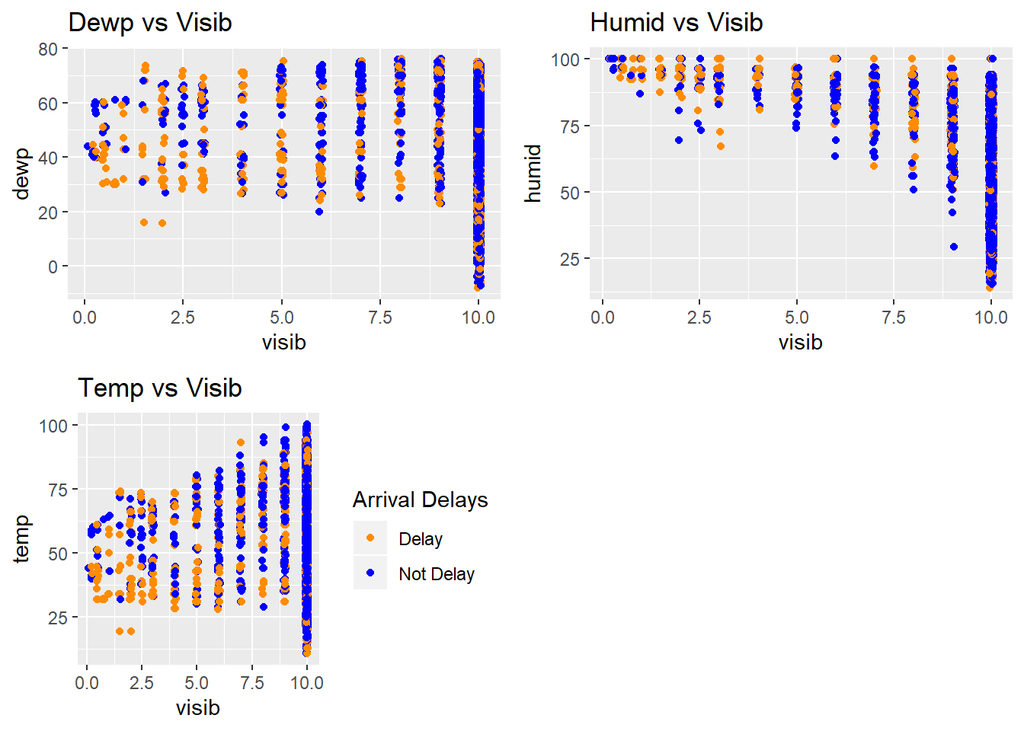

```r
cowplot::plot_grid(g5,g6,g7)
```

More feature engineering after exploring data.

```r
#create is_weekend column
joined <- joined %>%
  mutate(is_weekend = ifelse(weekdays == "Saturday" | weekdays == "Sunday",
                             "Weekend", "Not Weekend"))
joined$is_weekend <- as.factor(joined$is_weekend)

#create bad_weather column using precip and visib
joined <- joined %>%
  mutate(bad_weather = ifelse(precip >= 0.025 | visib <= 2.5, 2, 1))

#create air_time column (time from departure to scheduled arrival)
joined <- joined %>%
  mutate(air_time = sched_arr_time - dep_time) %>%
  mutate(air_time_class = ifelse(air_time < mean(air_time), 2, 1))

#remove not useful columns
colnames(joined)
```

```
##  [1] "month"           "day"             "hour"
##  [4] "time_hour"       "dep_time"        "sched_dep_time"
##  [7] "dep_delay"       "sched_arr_time"  "arr_delay"
## [10] "carrier"         "tailnum"         "temp"
## [13] "dewp"            "humid"           "wind_dir"
## [16] "wind_speed"      "precip"          "visib"
## [19] "dep_period"      "weekdays"        "dep_delay_class"
## [22] "is_weekend"      "bad_weather"     "air_time"
## [25] "air_time_class"
```

```r
joined_f <- joined[,c(3,7,9:10,12:14,16:25)]
```

Proportion of target variable is approximately having 1 delay out of 3 flights. The baseline accuracy is 66.3%, and subsequent prediction models should have no accuracy below is number.

```r
#data proportion
prop.table(table(joined_f$arr_delay))*100
```

```
##
##     Delay Not Delay
##  33.69032  66.30968
```

```r
#baseline accuracy
acc_base <- 66.3
```

### Model Fitting

3 Machine Learning algorithms are used to build models, namely K-nearest neighours, random forest and logistic regression. Data is processed according the requirements of each algorithm. The model is cross-validated by splitting the data into train and test sets to carry out evaluation via confusion matrix metrics.

```r
library(class)
library(caret)
#knn
colnames(joined_f)
```

```
##  [1] "hour"            "dep_delay"       "arr_delay"
##  [4] "carrier"         "temp"            "dewp"
##  [7] "humid"           "wind_speed"      "precip"
## [10] "visib"           "dep_period"      "weekdays"
## [13] "dep_delay_class" "is_weekend"      "bad_weather"
## [16] "air_time"        "air_time_class"
```

```r
joined2 <- joined_f[,c(2:3, 5:6, 8:10, 13,15:17)]

#scale data
joined2_n <- as.data.frame(lapply(joined2[,-2], scale))
#split data into train and test set
set.seed(123)
split <- sample(nrow(joined2), nrow(joined2)*0.8)

train_knn <- joined2_n[split, ]
test_knn <- joined2_n[-split, ]

train_labels <- joined2[split,2]
test_labels <- joined2[-split,2]

#check train and test sets
dim(joined2)
```

```
## [1] 4482   11
```

```r
dim(train_knn)
```

```
## [1] 3585   10
```

```r
dim(test_knn)
```

```
## [1] 897  10
```

```r
#check proportion
prop.table(table(train_labels))
```

```
## train_labels
##     Delay Not Delay
## 0.3305439 0.6694561
```

```r
#build model
sqrt(nrow(joined2))
```

```
## [1] 66.94774
```

```r
set.seed(123)
fit_knn <- knn(train = train_knn, test = test_knn, cl = train_labels, k=67)

#model evaluation
data.frame("predicted"=fit_knn,"actual"=test_labels)
```

```
##     predicted    actual
## 1   Not Delay     Delay
## 2   Not Delay Not Delay
## 3   Not Delay Not Delay
## 4   Not Delay Not Delay
## 5   Not Delay     Delay
## 6   Not Delay Not Delay
## 7   Not Delay     Delay
## 8   Not Delay Not Delay
## 9   Not Delay Not Delay
## 10      Delay     Delay
## 11  Not Delay Not Delay
## 12  Not Delay Not Delay
## 13  Not Delay     Delay
## 14  Not Delay     Delay
```

[output cut: 883 more lines]

```r
confusionMatrix(fit_knn,test_labels)
```

```
## Confusion Matrix and Statistics
##
##            Reference
## Prediction  Delay Not Delay
##   Delay       179        22
##   Not Delay   146       550
##
##                Accuracy : 0.8127
##                  95% CI : (0.7856, 0.8377)
##     No Information Rate : 0.6377
##     P-Value [Acc > NIR] : < 2.2e-16
##
##                   Kappa : 0.5583
##
##  Mcnemar's Test P-Value : < 2.2e-16
##
##             Sensitivity : 0.5508
##             Specificity : 0.9615
##          Pos Pred Value : 0.8905
##          Neg Pred Value : 0.7902
##              Prevalence : 0.3623
##          Detection Rate : 0.1996
##    Detection Prevalence : 0.2241
##       Balanced Accuracy : 0.7562
##
##        'Positive' Class : Delay
##
```

```r
knn_acc <- round((179+550)/(897),3)
knn_sens <- round(179/(179+146),3)
knn_spec <- round(550/(550+22),3)
knn_prec <- round(179/(179+22),3)
knn_vals <- c(knn_acc,knn_sens,knn_spec,knn_prec)
```

```r
#random forest
library(randomForest)
colnames(joined_f)
```

```
##  [1] "hour"            "dep_delay"       "arr_delay"
##  [4] "carrier"         "temp"            "dewp"
##  [7] "humid"           "wind_speed"      "precip"
## [10] "visib"           "dep_period"      "weekdays"
## [13] "dep_delay_class" "is_weekend"      "bad_weather"
## [16] "air_time"        "air_time_class"
```

```r
set.seed(234)
split2 <- sample(nrow(joined_f), nrow(joined_f)*0.8)
train_rf <- joined_f[split2, ]
test_rf <- joined_f[-split2, ]

train_rf_labels <- joined_f[split,3]
test_rf_labels <- joined_f[-split,3]

#check size of train and test sets
dim(train_rf)
```

```
## [1] 3585   17
```

```r
dim(test_rf)
```

```
## [1] 897  17
```

```r
#check proportion
prop.table(table(train_rf_labels))*100
```

```
## train_rf_labels
##     Delay Not Delay
##  33.05439  66.94561
```

```r
#build model
set.seed(101)
fit_rf <- train(arr_delay ~., data = train_rf, method= "rf", trControl= trainControl("repeatedcv", number=5, repeats = 3), importance=T)

varImp(fit_rf)
```

```
## rf variable importance
##
##   only 20 most important variables shown (out of 36)
##
##                     Importance
## dep_delay               100.00
## dep_delay_class          87.80
## air_time                 87.13
## air_time_class           70.93
## precip                   64.30
## humid                    47.39
## visib                    43.68
## bad_weather              43.42
## carrierUS                38.04
## dewp                     34.44
## hour14                   30.65
## temp                     29.56
## wind_speed               28.82
## weekdaysSaturday         28.65
## hour19                   27.33
## is_weekendWeekend        26.50
## hour6                    25.88
## hour13                   24.09
## dep_periodEvening        21.32
## dep_periodAfternoon      21.21
```

```r
fit_rf$finalModel
```

```
##
## Call:
##  randomForest(x = x, y = y, mtry = param$mtry, importance = ..1)
##                Type of random forest: classification
##                      Number of trees: 500
## No. of variables tried at each split: 2
##
##         OOB estimate of  error rate: 15.54%
## Confusion matrix:
##           Delay Not Delay class.error
## Delay       674       515  0.43313709
## Not Delay    42      2354  0.01752922
```

```r
tuneRF(train_rf[,-3], train_rf[,3], stepFactor = 1.5, improve = 1e-5)
```

```
## mtry = 4  OOB error = 16.82%
## Searching left ...
## mtry = 3     OOB error = 16.37%
## 0.026534 1e-05
## mtry = 2     OOB error = 15.84%
## 0.03236797 1e-05
## Searching right ...
## mtry = 6     OOB error = 16.71%
## -0.05457746 1e-05
```

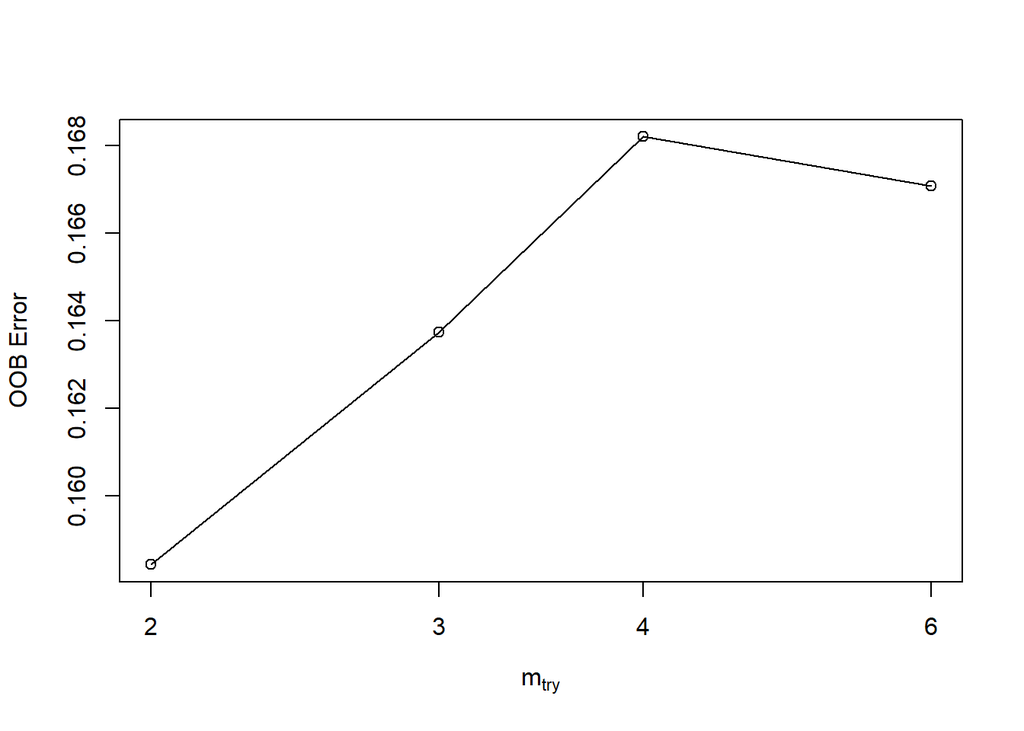

```
##       mtry  OOBError
## 2.OOB    2 0.1584379
## 3.OOB    3 0.1637378
## 4.OOB    4 0.1682008
## 6.OOB    6 0.1670851
```

```r
#model evaluation
pred_rf <- predict(fit_rf,test_rf)
data.frame("predicted"=pred_rf, "actual"=test_rf_labels)
```

```
##     predicted    actual
## 1   Not Delay     Delay
## 2   Not Delay Not Delay
## 3   Not Delay Not Delay
## 4   Not Delay Not Delay
## 5   Not Delay     Delay
## 6   Not Delay Not Delay
## 7   Not Delay     Delay
## 8   Not Delay Not Delay
## 9       Delay Not Delay
## 10      Delay     Delay
## 11  Not Delay Not Delay
## 12  Not Delay Not Delay
## 13      Delay     Delay
## 14  Not Delay     Delay
```

[output cut: 883 more lines]

```r
confusionMatrix(pred_rf,test_rf_labels)
```

```
## Confusion Matrix and Statistics
##
##            Reference
## Prediction  Delay Not Delay
##   Delay        72       112
##   Not Delay   253       460
##
##                Accuracy : 0.5931
##                  95% CI : (0.5601, 0.6254)
##     No Information Rate : 0.6377
##     P-Value [Acc > NIR] : 0.9974
##
##                   Kappa : 0.0284
##
##  Mcnemar's Test P-Value : 2.337e-13
##
##             Sensitivity : 0.22154
##             Specificity : 0.80420
##          Pos Pred Value : 0.39130
##          Neg Pred Value : 0.64516
##              Prevalence : 0.36232
##          Detection Rate : 0.08027
##    Detection Prevalence : 0.20513
##       Balanced Accuracy : 0.51287
##
##        'Positive' Class : Delay
##
```

```r
rf_acc <- round((72+460)/897,3)
rf_sens <- round(72/(72+253),3)
rf_spec <- round(460/(460+112),3)
rf_prec <- round(72/(72+112),3)
rf_vals <- c(rf_acc,rf_sens,rf_spec,rf_prec)
```

```r
#logistic regression
str(joined_f)
```

```
## 'data.frame':    4482 obs. of  17 variables:
##  $ hour           : Factor w/ 15 levels "5","6","8","9",..: 5 7 9 9 11 12 13 2 2 3 ...
##  $ dep_delay      : int  -5 -1 8 -3 -5 -4 19 -1 -2 -4 ...
##  $ arr_delay      : Factor w/ 2 levels "Delay","Not Delay": 2 2 1 2 2 1 1 2 2 1 ...
##  $ carrier        : Factor w/ 3 levels "EV","UA","US": 3 3 1 3 3 3 1 3 3 3 ...
##  $ temp           : num  41 39.2 37.9 37.9 36 ...
##  $ dewp           : num  28 28.4 24.1 24.1 19 ...
##  $ humid          : num  59.6 69.7 57 57 49.8 ...
##  $ wind_speed     : num  13.81 16.11 9.21 9.21 11.51 ...
##  $ precip         : num  0 0 0 0 0 0 0 0 0 0 ...
##  $ visib          : num  10 10 10 10 10 10 10 10 10 10 ...
##  $ dep_period     : Factor w/ 3 levels "Morning","Afternoon",..: 1 2 2 2 3 3 3 1 1 1 ...
##  $ weekdays       : Factor w/ 7 levels "Monday","Tuesday",..: 2 2 2 2 2 2 2 2 2 2 ...
##  $ dep_delay_class: num  1 1 1 1 1 1 2 1 1 1 ...
##  $ is_weekend     : Factor w/ 2 levels "Not Weekend",..: 1 1 1 1 1 1 1 1 1 1 ...
##  $ bad_weather    : num  1 1 1 1 1 1 1 1 1 1 ...
##  $ air_time       : int  200 191 190 199 201 207 188 204 205 205 ...
##  $ air_time_class : num  1 1 1 1 1 1 1 1 1 1 ...
```

```r
set.seed(350)
split3 <- sample(nrow(joined_f), nrow(joined_f)*0.8)
train_log <- joined_f[split3,]
test_log <- joined_f[-split3,]

#check dimensions of train and test sets
dim(train_log)
```

```
## [1] 3585   17
```

```r
dim(test_log)
```

```
## [1] 897  17
```

```r
#check proportion of target variable
prop.table(table(train_log$arr_delay))*100
```

```
##
##     Delay Not Delay
##  33.08229  66.91771
```

```r
#build model
fit_log <- glm(arr_delay ~., data = train_log, family = "binomial")
summary(fit_log)
```

```
##
## Call:
## glm(formula = arr_delay ~ ., family = "binomial", data = train_log)
##
## Deviance Residuals:
##      Min        1Q    Median        3Q       Max
## -2.55846  -0.04988   0.42832   0.59036   2.69637
##
## Coefficients: (3 not defined because of singularities)
##                      Estimate Std. Error z value Pr(>|z|)
## (Intercept)          0.950605   1.660562   0.572 0.567011
## hour6               -0.639094   0.243206  -2.628 0.008594 **
## hour8               -0.580466   0.280892  -2.067 0.038781 *
## hour9               -0.311199   0.374031  -0.832 0.405401
## hour10              -0.772979   0.285083  -2.711 0.006700 **
## hour12              -0.510847   0.353560  -1.445 0.148496
## hour13              -0.862763   0.291699  -2.958 0.003099 **
## hour14              -1.895169   0.534771  -3.544 0.000394 ***
## hour15              -1.219758   0.276841  -4.406 1.05e-05 ***
## hour16              -1.988870   0.807076  -2.464 0.013728 *
## hour17              -1.018365   0.295952  -3.441 0.000580 ***
## hour18              -0.608177   0.322145  -1.888 0.059039 .
## hour19              -0.811497   0.363790  -2.231 0.025703 *
## hour20              -0.149454   0.850834  -0.176 0.860564
## hour21              -0.440414   0.361044  -1.220 0.222527
## dep_delay           -0.116940   0.010154 -11.516  < 2e-16 ***
## carrierUA           -0.995447   1.449942  -0.687 0.492371
## carrierUS            0.292555   0.162476   1.801 0.071765 .
## temp                 0.019563   0.028789   0.680 0.496809
## dewp                -0.006113   0.030983  -0.197 0.843593
## humid               -0.008856   0.015298  -0.579 0.562663
## wind_speed          -0.018004   0.010372  -1.736 0.082597 .
## precip              -3.378679   1.876863  -1.800 0.071833 .
## visib                0.033002   0.041835   0.789 0.430191
## dep_periodAfternoon        NA         NA      NA       NA
## dep_periodEvening          NA         NA      NA       NA
## weekdaysTuesday      0.101724   0.180537   0.563 0.573126
## weekdaysWednesday   -0.107519   0.177568  -0.606 0.544843
## weekdaysThursday    -0.208645   0.175026  -1.192 0.233228
## weekdaysFriday       0.262870   0.183198   1.435 0.151318
## weekdaysSaturday     0.689348   0.206374   3.340 0.000837 ***
## weekdaysSunday       0.460313   0.193907   2.374 0.017602 *
## dep_delay_class     -0.744006   0.344182  -2.162 0.030644 *
## is_weekendWeekend          NA         NA      NA       NA
## bad_weather         -0.508127   0.339861  -1.495 0.134888
## air_time             0.007706   0.001329   5.801 6.60e-09 ***
## air_time_class      -0.075841   0.211000  -0.359 0.719269
## ---
## Signif. codes:  0 '***' 0.001 '**' 0.01 '*' 0.05 '.' 0.1 ' ' 1
##
## (Dispersion parameter for binomial family taken to be 1)
##
##     Null deviance: 4551.2  on 3584  degrees of freedom
## Residual deviance: 2628.2  on 3551  degrees of freedom
## AIC: 2696.2
##
## Number of Fisher Scoring iterations: 7
```

```r
#stepwise to choose optimum variables
fit_log_step <- step(fit_log, trace=T)
```

```
## Start:  AIC=2696.16
## arr_delay ~ hour + dep_delay + carrier + temp + dewp + humid +
##     wind_speed + precip + visib + dep_period + weekdays + dep_delay_class +
##     is_weekend + bad_weather + air_time + air_time_class
```

[output not shown]

```
##
## Step:  AIC=2696.16
## arr_delay ~ hour + dep_delay + carrier + temp + dewp + humid +
##     wind_speed + precip + visib + dep_period + weekdays + dep_delay_class +
##     bad_weather + air_time + air_time_class
```

```
##
## Step:  AIC=2696.16
## arr_delay ~ hour + dep_delay + carrier + temp + dewp + humid +
##     wind_speed + precip + visib + weekdays + dep_delay_class +
##     bad_weather + air_time + air_time_class
```

```
##                   Df Deviance    AIC
## - dewp             1   2628.2 2694.2
## - air_time_class   1   2628.3 2694.3
## - humid            1   2628.5 2694.5
## - temp             1   2628.6 2694.6
## - visib            1   2628.8 2694.8
## - carrier          2   2632.0 2696.0
## <none>                 2628.2 2696.2
## - bad_weather      1   2630.4 2696.4
## - wind_speed       1   2631.2 2697.2
## - precip           1   2631.7 2697.7
## - dep_delay_class  1   2633.1 2699.1
## - air_time         1   2635.5 2701.5
## - hour            14   2666.5 2706.5
## - weekdays         6   2660.2 2716.2
## - dep_delay        1   2788.8 2854.8
```

```
##
## Step:  AIC=2694.2
## arr_delay ~ hour + dep_delay + carrier + temp + humid + wind_speed +
##     precip + visib + weekdays + dep_delay_class + bad_weather +
##     air_time + air_time_class
```

```
##                   Df Deviance    AIC
## - air_time_class   1   2628.3 2692.3
## - visib            1   2628.8 2692.8
## - carrier          2   2632.0 2694.0
## <none>                 2628.2 2694.2
## - bad_weather      1   2630.4 2694.4
## - wind_speed       1   2631.2 2695.2
## - precip           1   2631.7 2695.7
## - dep_delay_class  1   2633.2 2697.2
## - air_time         1   2635.5 2699.5
## - humid            1   2638.4 2702.4
## - hour            14   2666.5 2704.5
## - temp             1   2650.1 2714.1
## - weekdays         6   2660.4 2714.4
## - dep_delay        1   2788.8 2852.8
```

```
##
## Step:  AIC=2692.33
## arr_delay ~ hour + dep_delay + carrier + temp + humid + wind_speed +
##     precip + visib + weekdays + dep_delay_class + bad_weather +
##     air_time
```

```
##                   Df Deviance    AIC
## - visib            1   2628.9 2690.9
## - carrier          2   2632.0 2692.0
## <none>                 2628.3 2692.3
## - bad_weather      1   2630.5 2692.5
## - wind_speed       1   2631.3 2693.3
## - precip           1   2631.8 2693.8
## - dep_delay_class  1   2633.3 2695.3
## - air_time         1   2636.9 2698.9
## - humid            1   2638.4 2700.4
## - hour            14   2666.6 2702.6
## - temp             1   2650.3 2712.3
## - weekdays         6   2660.5 2712.5
## - dep_delay        1   2877.0 2939.0
```

```
##
## Step:  AIC=2690.93
## arr_delay ~ hour + dep_delay + carrier + temp + humid + wind_speed +
##     precip + weekdays + dep_delay_class + bad_weather + air_time
```

```
##                   Df Deviance    AIC
## - carrier          2   2632.6 2690.6
## <none>                 2628.9 2690.9
## - wind_speed       1   2631.7 2691.7
## - precip           1   2632.2 2692.2
## - dep_delay_class  1   2634.0 2694.0
## - bad_weather      1   2634.6 2694.6
## - air_time         1   2637.5 2697.5
## - humid            1   2643.0 2703.0
## - hour            14   2669.3 2703.3
## - weekdays         6   2661.2 2711.2
## - temp             1   2652.2 2712.2
## - dep_delay        1   2877.1 2937.1
```

```
##
## Step:  AIC=2690.59
## arr_delay ~ hour + dep_delay + temp + humid + wind_speed + precip +
##     weekdays + dep_delay_class + bad_weather + air_time
```

```
##                   Df Deviance    AIC
## <none>                 2632.6 2690.6
## - wind_speed       1   2635.3 2691.3
## - precip           1   2635.8 2691.8
## - dep_delay_class  1   2637.5 2693.5
## - bad_weather      1   2638.1 2694.1
## - air_time         1   2639.5 2695.5
## - humid            1   2646.9 2702.9
## - hour            14   2674.4 2704.4
## - weekdays         6   2666.0 2712.0
## - temp             1   2656.6 2712.6
## - dep_delay        1   2887.3 2943.3
```

```r
summary(fit_log_step)
```

```
##
## Call:
## glm(formula = arr_delay ~ hour + dep_delay + temp + humid + wind_speed +
##     precip + weekdays + dep_delay_class + bad_weather + air_time,
##     family = "binomial", data = train_log)
##
## Deviance Residuals:
##     Min       1Q   Median       3Q      Max
## -2.5906  -0.0476   0.4288   0.5938   2.7199
##
## Coefficients:
##                    Estimate Std. Error z value Pr(>|z|)
## (Intercept)        1.865064   0.626020   2.979 0.002890 **
## hour6             -0.716789   0.233442  -3.071 0.002137 **
## hour8             -0.620701   0.273760  -2.267 0.023371 *
## hour9             -0.619190   0.331924  -1.865 0.062117 .
## hour10            -0.789537   0.279111  -2.829 0.004673 **
## hour12            -0.812470   0.311583  -2.608 0.009119 **
## hour13            -0.892550   0.284706  -3.135 0.001719 **
## hour14            -2.215896   0.506246  -4.377 1.20e-05 ***
## hour15            -1.338572   0.266146  -5.029 4.92e-07 ***
## hour16            -2.024799   0.802928  -2.522 0.011677 *
## hour17            -1.023198   0.288232  -3.550 0.000385 ***
## hour18            -0.618419   0.316438  -1.954 0.050664 .
## hour19            -1.092645   0.321650  -3.397 0.000681 ***
## hour20            -0.439918   0.840059  -0.524 0.600504
## hour21            -0.717452   0.324651  -2.210 0.027111 *
## dep_delay         -0.120158   0.008302 -14.474  < 2e-16 ***
## temp               0.014238   0.002922   4.872 1.10e-06 ***
## humid             -0.012882   0.003402  -3.786 0.000153 ***
## wind_speed        -0.016931   0.010315  -1.641 0.100718
## precip            -3.169389   1.850918  -1.712 0.086835 .
## weekdaysTuesday    0.104183   0.180110   0.578 0.562967
## weekdaysWednesday -0.112698   0.177252  -0.636 0.524900
## weekdaysThursday  -0.209493   0.174896  -1.198 0.230990
## weekdaysFriday     0.263884   0.182903   1.443 0.149091
## weekdaysSaturday   0.698978   0.205783   3.397 0.000682 ***
## weekdaysSunday     0.475164   0.193384   2.457 0.014006 *
## dep_delay_class   -0.739044   0.343304  -2.153 0.031339 *
## bad_weather       -0.646509   0.271032  -2.385 0.017063 *
## air_time           0.007796   0.001319   5.912 3.38e-09 ***
## ---
## Signif. codes:  0 '***' 0.001 '**' 0.01 '*' 0.05 '.' 0.1 ' ' 1
##
## (Dispersion parameter for binomial family taken to be 1)
##
##     Null deviance: 4551.2  on 3584  degrees of freedom
## Residual deviance: 2632.6  on 3556  degrees of freedom
## AIC: 2690.6
##
## Number of Fisher Scoring iterations: 7
```

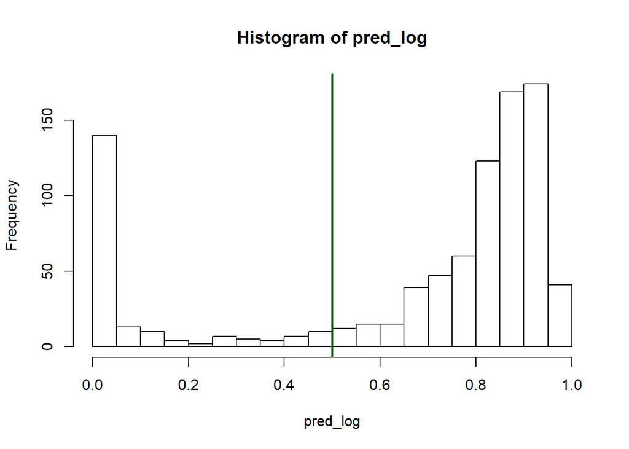

```r
#prediction
pred_log <- predict(fit_log_step,test_log, type="response")
hist(pred_log, breaks=20)
abline(v=0.5, col="darkgreen", lwd=2)
```

```r
table("predicted"=as.numeric(pred_log >= 0.77), "actual"=as.numeric(test_log$arr_delay))
```

```
##          actual
## predicted   1   2
##         0 243 110
##         1  81 463
```

```r
pred_factor <- factor(as.numeric(pred_log >= 0.77), levels = c(0,1), labels=c("Delay","Not Delay"))
confusionMatrix(pred_factor, test_log$arr_delay)
```

```
## Confusion Matrix and Statistics
##
##            Reference
## Prediction  Delay Not Delay
##   Delay       243       110
##   Not Delay    81       463
##
##                Accuracy : 0.7871
##                  95% CI : (0.7588, 0.8134)
##     No Information Rate : 0.6388
##     P-Value [Acc > NIR] : < 2e-16
##
##                   Kappa : 0.5474
##
##  Mcnemar's Test P-Value : 0.04276
##
##             Sensitivity : 0.7500
##             Specificity : 0.8080
##          Pos Pred Value : 0.6884
##          Neg Pred Value : 0.8511
##              Prevalence : 0.3612
##          Detection Rate : 0.2709
##    Detection Prevalence : 0.3935
##       Balanced Accuracy : 0.7790
##
##        'Positive' Class : Delay
##
```

```r
#model 2 (9 variables which are chosen to avoid overfitting of train set)
fit_log2 <- glm(formula = arr_delay ~ dep_delay + wind_speed + is_weekend + temp + dewp + dep_delay_class + bad_weather + air_time_class + dep_period,
    family = "binomial", data = train_log)
summary(fit_log2)
```

```
##
## Call:
## glm(formula = arr_delay ~ dep_delay + wind_speed + is_weekend +
##     temp + dewp + dep_delay_class + bad_weather + air_time_class +
##     dep_period, family = "binomial", data = train_log)
##
## Deviance Residuals:
##      Min        1Q    Median        3Q       Max
## -2.52004  -0.05408   0.45118   0.59393   2.78553
##
## Coefficients:
##                      Estimate Std. Error z value Pr(>|z|)
## (Intercept)          2.376441   0.510753   4.653 3.27e-06 ***
## dep_delay           -0.128809   0.010196 -12.633  < 2e-16 ***
## wind_speed          -0.016193   0.010036  -1.614   0.1066
## is_weekendWeekend    0.598089   0.120855   4.949 7.47e-07 ***
## temp                 0.031845   0.007292   4.367 1.26e-05 ***
## dewp                -0.020783   0.006759  -3.075   0.0021 **
## dep_delay_class     -0.709818   0.338940  -2.094   0.0362 *
## bad_weather         -1.068963   0.209558  -5.101 3.38e-07 ***
## air_time_class      -0.125858   0.185426  -0.679   0.4973
## dep_periodAfternoon -0.526006   0.133604  -3.937 8.25e-05 ***
## dep_periodEvening   -0.191632   0.137069  -1.398   0.1621
## ---
## Signif. codes:  0 '***' 0.001 '**' 0.01 '*' 0.05 '.' 0.1 ' ' 1
##
## (Dispersion parameter for binomial family taken to be 1)
##
##     Null deviance: 4551.2  on 3584  degrees of freedom
## Residual deviance: 2677.8  on 3574  degrees of freedom
## AIC: 2699.8
##
## Number of Fisher Scoring iterations: 7
```

```r
pred_log2 <- predict(fit_log2,test_log, type="response")
table("predicted"=as.numeric(pred_log2 >= 0.7), "actual"=as.numeric(test_log$arr_delay))
```

```
##          actual
## predicted   1   2
##         0 215  51
##         1 109 522
```

```r
pred_factor2 <- factor(as.numeric(pred_log2 >= 0.786), levels = c(0,1), labels=c("Delay","Not Delay"))
confusionMatrix(pred_factor2, test_log$arr_delay)
```

```
## Confusion Matrix and Statistics
##
##            Reference
## Prediction  Delay Not Delay
##   Delay       244       111
##   Not Delay    80       462
##
##                Accuracy : 0.7871
##                  95% CI : (0.7588, 0.8134)
##     No Information Rate : 0.6388
##     P-Value [Acc > NIR] : < 2e-16
##
##                   Kappa : 0.548
##
##  Mcnemar's Test P-Value : 0.02995
##
##             Sensitivity : 0.7531
##             Specificity : 0.8063
##          Pos Pred Value : 0.6873
##          Neg Pred Value : 0.8524
##              Prevalence : 0.3612
##          Detection Rate : 0.2720
##    Detection Prevalence : 0.3958
##       Balanced Accuracy : 0.7797
##
##        'Positive' Class : Delay
##
```

```r
log_acc <- round((244+462)/897,3)
log_sens <- round(244/(244+80),3)
log_spec <- round(462/(462+111),3)
log_prec <- round(244/(244+111),3)
log_vals <- c(log_acc,log_sens,log_spec,log_prec)
```

### Comparing models

```r
paste("Baseline Accuracy: ",acc_base,"%")
```

```
## [1] "Baseline Accuracy:  66.3 %"
```

```r
data.frame(row.names = c("Accuracy", "Sensitivity", "Specificity", "Precision"), cbind(knn_vals,rf_vals,log_vals))
```

```
##             knn_vals rf_vals log_vals
## Accuracy       0.813   0.593    0.787
## Sensitivity    0.551   0.222    0.753
## Specificity    0.962   0.804    0.806
## Precision      0.891   0.391    0.687
```

```r
#evaluation set
submission <- read.csv("case_data/data-submission.csv")

#convert data to fit model
str(submission)
```

```
## 'data.frame':    399 obs. of  15 variables:
##  $ month           : int  12 12 12 12 12 12 12 12 12 12 ...
##  $ day             : Factor w/ 7 levels "Fri","Mon","Sat",..: 4 4 4 4 4 4 4 4 4 4 ...
##  $ dep_delay       : int  -7 -7 6 -4 -3 -7 -8 49 -6 -7 ...
##  $ sched_arr_hour  : int  6 8 8 8 10 12 15 14 16 17 ...
##  $ sched_arr_minute: int  51 11 17 35 21 18 6 30 56 21 ...
##  $ sched_dep_hour  : int  5 6 6 6 8 10 13 12 15 15 ...
##  $ sched_dep_minute: int  0 1 15 30 20 23 15 29 0 20 ...
##  $ temp            : num  35.1 33.8 33.8 33.8 39 ...
##  $ dewp            : num  28 26.6 26.6 26.6 30.9 ...
##  $ humid           : num  75.3 78.5 78.5 78.5 72.5 ...
##  $ wind_dir        : int  10 40 40 40 30 0 210 230 210 210 ...
##  $ wind_speed      : num  4.6 5.75 5.75 5.75 3.45 ...
##  $ precip          : num  0 0 0 0 0 0 0 0 0 0 ...
##  $ visib           : num  10 10 10 10 10 10 10 10 10 10 ...
##  $ arr_status      : logi  NA NA NA NA NA NA ...
```

```r
#check missing values
colSums(is.na(submission))
```

```
##            month              day        dep_delay   sched_arr_hour
##                0                0                0                0
## sched_arr_minute   sched_dep_hour sched_dep_minute             temp
##                0                0                0                0
##             dewp            humid         wind_dir       wind_speed
##                0                0                0                0
##           precip            visib       arr_status
##                0                0              399
```

```r
#create feature engineered columns
submission <- submission %>%
  mutate(sched_arr_time = ifelse(sched_arr_minute <10,
                                 paste0(sched_arr_hour, 0, sched_arr_minute),
                                 paste0(sched_arr_hour, sched_arr_minute))) %>%
  mutate(sched_dep_time = ifelse(sched_dep_minute<10,
                                 paste0(sched_dep_hour, 0, sched_dep_minute),
                                 paste0(sched_dep_hour, sched_dep_minute)))

submission$sched_arr_time <- as.numeric(submission$sched_arr_time)
submission$sched_dep_time <- as.numeric(submission$sched_dep_time)

submission <- submission %>%
  mutate(dep_time = sched_dep_time + dep_delay)

submission2 <- submission %>%
  mutate(is_weekend = ifelse(day == "Saturday" | day == "Sunday", "Weekend", "Not Weekend")) %>%
  mutate(dep_delay_class = case_when(dep_delay <= 15 ~ 1,
                                     dep_delay >  15 ~ 2)) %>%
  mutate(bad_weather = ifelse(precip >= 0.025 | visib <= 2.5, 2, 1))
submission2$is_weekend <- as.factor(submission2$is_weekend)
library(tidyr)
sep_dep_time <- submission2 %>%
  separate(dep_time, into=c("hour", "minute"), sep = -2, convert = TRUE)

submission2$hour <- sep_dep_time$hour

submission2 <- submission2 %>%
  mutate(dep_period = case_when(hour <=10 ~ "Morning",
                                hour >10 & hour <=16 ~ "Afternoon",
                                hour >16 ~ "Evening")) %>%
  mutate(air_time = sched_arr_time - dep_time) %>%
  mutate(air_time_class = ifelse(air_time < mean(air_time), 2, 1))
submission2$dep_period <-  as.factor(submission2$dep_period)
submission2$hour <- as.factor(submission2$hour)

colnames(submission2)
```

```
##  [1] "month"            "day"              "dep_delay"
##  [4] "sched_arr_hour"   "sched_arr_minute" "sched_dep_hour"
##  [7] "sched_dep_minute" "temp"             "dewp"
## [10] "humid"            "wind_dir"         "wind_speed"
## [13] "precip"           "visib"            "arr_status"
## [16] "sched_arr_time"   "sched_dep_time"   "dep_time"
## [19] "is_weekend"       "dep_delay_class"  "bad_weather"
## [22] "hour"             "dep_period"       "air_time"
## [25] "air_time_class"
```

```r
#remove unnecessary columns
submission2 <- submission2[, c(2:3, 8:10, 12:14, 19:25)]

#predict using fit_log2 model
pred_unseen <- predict(fit_log2,submission2, type="response")

pred_factor_unseen <- factor(as.numeric(pred_unseen >= 0.786), levels = c(0,1), labels=c("Delay","Not Delay"))
subm <- cbind(submission, pred_factor_unseen)
subm <- subm[, c(1:14, 19)]
colnames(subm)
```

```
##  [1] "month"              "day"                "dep_delay"
##  [4] "sched_arr_hour"     "sched_arr_minute"   "sched_dep_hour"
##  [7] "sched_dep_minute"   "temp"               "dewp"
## [10] "humid"              "wind_dir"           "wind_speed"
## [13] "precip"             "visib"              "pred_factor_unseen"
```

```r
colnames(subm)[15] <- "arr_status"

#write.csv
results <- write.csv(x = subm, file = "Yvonne_airline13-cl-del.csv")
```

## Capstone Task

As a final step in machine learning course, every student should complete ONLY ONE case as their machine learning capstone project.

The dataset and rubrics are attached, separated by Case. Please note that “Case 3: Your own data set” still comes with a set of rubrics. Ensure that your data set is sufficiently difficult to be able to meet the rubrics before embarking.

Case 1: Food and Beverage The Food and Beverage dataset is provided by Dattabot, which contains detailed transactions of multiple food and beverage outlets. You will be challenged to do some forecasting and time series analysis to help the outlet’s owner make better business decisions.

**Case 2: Airline13: “The Late List”** `Flight delays and travel interruptions can put a real strain on traveler’s wallet, plans and sanity. Major airline companies have begun to develop an early notification system about delays. Using “Airline13” dataset, make a prediction model to classify the arrival status (Delay vs Not Delay) of a flight that would be evaluated on December 2013.`

Case 3: Your own data set You are free to use your own data set to do machine learning predictions. To ensure that there is sufficient difficulty in the data-set, please discuss with your trainer before embarking on the project. Note that if the data is too “clean”, it will not make a good project! Be sure to check with your trainers beforehand.